# UW_Summary_Fall_Pilot_Data_2026

Author

Ruth Williamson, Slayer of Data and Scurge of the Analysis

Published

November 9, 2026

# Read Me!

## **In Brief**

# **Data Import and Cleaning**

### Load in libraries :)

```r
library(tidyverse)
library(cowplot)
library(readxl)
theme_set(theme_cowplot())
library(factoextra)
library(wesanderson)
library(gt)
library(openxlsx)
library(nlme)
library(lmtest)
library(AICcmodavg)
library(lattice)
library(chemhelper) #for retention index calculations
library(janitor)
library(snakecase)
pal <- wes_palette(name = "Zissou1")
```

### Read in the data!

```r
phyto_dat <- read.csv("phytoncide_dat")

phyto_dat$brand <- factor(phyto_dat$brand)
phyto_dat$location <- factor(phyto_dat$location)

glimpse(phyto_dat)
```

```
Rows: 420
Columns: 24
$ project                 <chr> "test_october_2026", "test_october_2026", "tes…
$ type                    <chr> "control", "control", "control", "control", "c…
$ pump                    <chr> NA, NA, NA, NA, NA, NA, NA, NA, NA, NA, NA, NA…
$ brand                   <fct> control, control, control, control, control, c…
$ location                <fct> forest, forest, forest, forest, forest, forest…
$ year                    <int> 2026, 2026, 2026, 2026, 2026, 2026, 2026, 2026…
$ mix                     <chr> "mix1", "mix1", "mix1", "mix1", "mix1", "mix1"…
$ sample_id               <chr> "control_control_forest_2026_mix1", "control_c…
$ source_file             <chr> "control_g_sp_mix1.xml", "control_g_sp_mix1.xm…
$ number                  <int> 1, 2, 3, 4, 5, 6, 7, 8, 9, 10, 1, 2, 3, 4, 5, …
$ peak_name               <chr> "camphene", "alpha_phellandrene", "limonene", …
$ retention_time          <dbl> 0, 0, 0, 0, 0, 0, 0, 0, 0, 0, 0, 0, 0, 0, 0, 0…
$ amount                  <dbl> 0, 0, 0, 0, 0, 0, 0, 0, 0, 0, 0, 0, 0, 0, 0, 0…
$ peak_area               <int> 0, 0, 0, 0, 0, 0, 0, 0, 0, 0, 0, 0, 0, 0, 0, 0…
$ units                   <chr> "ppm", "ppm", "ppm", "ppm", "ppm", "ppm", "ppm…
$ cal_istd                <int> 0, 0, 0, 0, 0, 0, 0, 0, 0, 0, 0, 0, 0, 0, 0, 0…
$ q_value                 <int> 0, 0, 0, 0, 0, 0, 0, 0, 0, 0, 0, 0, 0, 0, 0, 0…
$ expected_retention_time <dbl> 9.703, 10.316, 10.613, 10.702, 11.315, 12.365,…
$ target_ion              <dbl> 93.1, 93.1, 93.0, 93.1, 121.1, 71.1, 120.0, 95…
$ qualifier1_ion          <dbl> 121.1, 91.0, 68.1, 91.1, 93.1, 93.0, 92.0, 121…
$ qualifier2_ion          <dbl> 79.0, 77.0, 67.1, 79.0, 136.1, 111.1, 152.0, 9…
$ qualifier3_ion          <int> 0, 0, 0, 0, 0, 0, 0, 0, 0, 0, 0, 0, 0, 0, 0, 0…
$ start_integration       <dbl> 9.203, 9.816, 10.113, 10.202, 10.815, 11.865, …
$ end_integration         <dbl> 10.203, 10.816, 11.113, 11.202, 11.815, 12.865…
```

```r
pump_dat <- read_xlsx("uw_test_field_sheet_oct_2026.xlsx", sheet = "tidy") |>
  select(c(location, pump, cubic_m))
glimpse(pump_dat)
```

```
Rows: 8
Columns: 3
$ location <chr> "urban", "urban", "urban", "urban", "forest", "forest", "fore…
$ pump     <chr> "p3", "p14", "pg2", "pg3", "p3", "p14", "pg2", "pg3"
$ cubic_m  <dbl> 0.01948127, 0.01648287, 0.02127700, 0.02136700, 0.01947138, 0…
```

#Joining on the shared columns

```r
dat_joined <- left_join(phyto_dat, pump_dat, by=join_by(pump,location))
#joined on the shared columns

glimpse(dat_joined)
```

```
Rows: 420
Columns: 25
$ project                 <chr> "test_october_2026", "test_october_2026", "tes…
$ type                    <chr> "control", "control", "control", "control", "c…
$ pump                    <chr> NA, NA, NA, NA, NA, NA, NA, NA, NA, NA, NA, NA…
$ brand                   <fct> control, control, control, control, control, c…
$ location                <chr> "forest", "forest", "forest", "forest", "fores…
$ year                    <int> 2026, 2026, 2026, 2026, 2026, 2026, 2026, 2026…
$ mix                     <chr> "mix1", "mix1", "mix1", "mix1", "mix1", "mix1"…
$ sample_id               <chr> "control_control_forest_2026_mix1", "control_c…
$ source_file             <chr> "control_g_sp_mix1.xml", "control_g_sp_mix1.xm…
$ number                  <int> 1, 2, 3, 4, 5, 6, 7, 8, 9, 10, 1, 2, 3, 4, 5, …
$ peak_name               <chr> "camphene", "alpha_phellandrene", "limonene", …
$ retention_time          <dbl> 0, 0, 0, 0, 0, 0, 0, 0, 0, 0, 0, 0, 0, 0, 0, 0…
$ amount                  <dbl> 0, 0, 0, 0, 0, 0, 0, 0, 0, 0, 0, 0, 0, 0, 0, 0…
$ peak_area               <int> 0, 0, 0, 0, 0, 0, 0, 0, 0, 0, 0, 0, 0, 0, 0, 0…
$ units                   <chr> "ppm", "ppm", "ppm", "ppm", "ppm", "ppm", "ppm…
$ cal_istd                <int> 0, 0, 0, 0, 0, 0, 0, 0, 0, 0, 0, 0, 0, 0, 0, 0…
$ q_value                 <int> 0, 0, 0, 0, 0, 0, 0, 0, 0, 0, 0, 0, 0, 0, 0, 0…
$ expected_retention_time <dbl> 9.703, 10.316, 10.613, 10.702, 11.315, 12.365,…
$ target_ion              <dbl> 93.1, 93.1, 93.0, 93.1, 121.1, 71.1, 120.0, 95…
$ qualifier1_ion          <dbl> 121.1, 91.0, 68.1, 91.1, 93.1, 93.0, 92.0, 121…
$ qualifier2_ion          <dbl> 79.0, 77.0, 67.1, 79.0, 136.1, 111.1, 152.0, 9…
$ qualifier3_ion          <int> 0, 0, 0, 0, 0, 0, 0, 0, 0, 0, 0, 0, 0, 0, 0, 0…
$ start_integration       <dbl> 9.203, 9.816, 10.113, 10.202, 10.815, 11.865, …
$ end_integration         <dbl> 10.203, 10.816, 11.113, 11.202, 11.815, 12.865…
$ cubic_m                 <dbl> NA, NA, NA, NA, NA, NA, NA, NA, NA, NA, NA, NA…
```

#correcting concentrations with volume

```r
dat <- dat_joined |>
  mutate(conc_ngcm = amount/cubic_m,
         conc_ugcm = conc_ngcm/1000)
```

#calculating LOD

```r
compound_info <- read_xlsx("compound_summary_table_info_2024.xlsx") |>
  mutate(lod = (3*concentration_ion)/(ion_signal/ion_noise),
         loq = (10*concentration_ion)/(ion_signal/ion_noise),
         lod_old = (3*concentration)/(signal/noise),
         loq_old = (10*concentration)/(signal/noise))

#the old LOD/LOQ was done in undergrad and I have gone through it again to make sure I understand it now and have adjusted it with how I would do it now since I have learned more.
```

LOD/LOQ of Compounds

LOD/LOQ of Compounds

| Compound | LOD | LOQ |
| --- | --- | --- |
| Alpha Copaene | 0.001 | 0.005 |
| Alpha Humulene | 0.027 | 0.091 |
| Alpha Phellandrene | 0.002 | 0.006 |
| Alpha Pinene | 0.005 | 0.017 |
| Alpha Terpinene | 0.004 | 0.012 |
| Alpha Terpineol | 0.004 | 0.012 |
| Beta Caryophyllene | 0.007 | 0.023 |
| Beta Farnesene | 13.714 | 45.714 |
| Beta Myrcene | 0.003 | 0.010 |
| Beta Phellandrene | 0.015 | 0.050 |
| Beta Pinene | 0.004 | 0.014 |
| Borneol | 0.002 | 0.007 |
| Bornyl Acetate | 0.004 | 0.015 |
| Camphene | 0.006 | 0.020 |
| Camphor | 0.002 | 0.008 |
| Cis three Hexen one ol | 0.009 | 0.030 |
| Citronellol | 2.478 | 8.259 |
| Eucalyptol | 1.679 | 5.597 |
| Eugenol | 0.004 | 0.015 |
| Fenchone | 0.001 | 0.004 |
| Gamma Terpinene | 0.002 | 0.007 |
| Limonene | 0.003 | 0.011 |
| Linalool | 0.008 | 0.026 |
| Linalool Oxide | 0.010 | 0.032 |
| Longifolene | 0.006 | 0.020 |
| Menthol | 1.277 | 4.255 |
| Methyl Jasmonate | 0.005 | 0.018 |
| Methyl Salicylate | 0.002 | 0.007 |
| Ocimene | 0.045 | 0.152 |
| one four cineole | 0.003 | 0.011 |
| p Cymene | 0.001 | 0.003 |
| Sabinene | 0.007 | 0.022 |
| Terpinen four ol | 0.003 | 0.009 |
| Terpinolene | 0.003 | 0.010 |
| Trimethyl Trideca | 0.003 | 0.011 |

# Retention Index Calculations

Retention indexes are calcuated by using the retention time of alkanes that proceed directly before and after the compound.The equation is as follows

> Ix = 100n + 100(tx-tn) / (tn+1 − tn)

The package I would like to use for this is: chemhelper by Eric R. Scott

To cite package ‘chemhelper’ in publications use:

Scott E (2023). chemhelper: Helper Functions For Dealing With GCMS and LCMS data from IonAnalytics. R package version 0.0.0.9000, https://github.com/aariq/chemhelper.

Getting just the retention times and compound names from the compound info table. These retention times are what the method used to find the compounds:

```r
xrt <- compound_info |>
  subset(select = c(name, rt)) |>
  mutate(name = to_snake_case(name)) #converting names to snakecase

nrt <- read_xlsx("Alkane_RT.xlsx") # reading in alkane rt info

xrt <- xrt|>
  mutate(ri = calc_RI(rt, nrt$rt, nrt$carbon_num))

#so now xrt has the RI calculations for our compounds
```

# trimming the tibble so I have less anxiety looking at it

```r
dat_smol <- dat |>
  select(type, pump, brand, location, sample_id, peak_name, retention_time, amount, peak_area, conc_ugcm, conc_ngcm) |>
  unite(id, pump, brand, location, sep = "_", remove = FALSE)
```

# General visualization of data

```r
dat_sum <- dat_smol |>
  group_by(brand, location, type, peak_name) |>
  summarise(conc_mean = mean(conc_ugcm),
            conc_stdv = sd(conc_ugcm),
            n = n()
            )
```

```
`summarise()` has regrouped the output.
ℹ Summaries were computed grouped by brand, location, type, and peak_name.
ℹ Output is grouped by brand, location, and type.
ℹ Use `summarise(.groups = "drop_last")` to silence this message.
ℹ Use `summarise(.by = c(brand, location, type, peak_name))` for per-operation
  grouping (`?dplyr::dplyr_by`) instead.
```

General Summary Table

General Summary (ug/m^3)

| peak_name | conc_mean | conc_stdv | n |
| --- | --- | --- | --- |
| gilair - forest - sample |  |  |  |
| alpha_phellandrene | 0.002 | 0.000 | 2 |
| alpha_pinene | 0.029 | 0.002 | 2 |
| alpha_terpinene | 0.002 | 0.000 | 2 |
| beta_myrcene | 0.004 | 0.001 | 2 |
| beta_ocimene | 0.003 | 0.001 | 2 |
| beta_phellandrene | 0.007 | 0.002 | 2 |
| beta_pinene | 0.005 | 0.001 | 2 |
| camphene | 0.009 | 0.012 | 2 |
| eucalyptol | 0.003 | 0.004 | 2 |
| fenchone | 0.004 | 0.001 | 2 |
| gamma_terpinene | 0.002 | 0.001 | 2 |
| limonene | 0.007 | 0.002 | 2 |
| linalool | 0.011 | 0.008 | 2 |
| menthol | 0.001 | 0.002 | 2 |
| methyl_salicylate | 0.001 | 0.001 | 2 |
| p_cymene | 0.007 | 0.001 | 2 |
| sabinene | 0.010 | 0.002 | 2 |
| terpinolene | 0.044 | 0.060 | 2 |
| gilair - urban - sample |  |  |  |
| alpha_phellandrene | 0.004 | 0.006 | 2 |
| alpha_pinene | 0.002 | 0.003 | 2 |
| alpha_terpinene | 0.005 | 0.003 | 2 |
| beta_citronellol | 0.005 | 0.000 | 2 |
| beta_ocimene | 0.002 | 0.000 | 2 |
| beta_phellandrene | 0.010 | 0.009 | 2 |
| camphene | 0.001 | 0.002 | 2 |
| eucalyptol | 0.002 | 0.003 | 2 |
| fenchone | 0.012 | 0.005 | 2 |
| gamma_terpinene | 0.001 | 0.000 | 2 |

[output cut: 59 more lines]

# Comparing forest SKC and Gilair

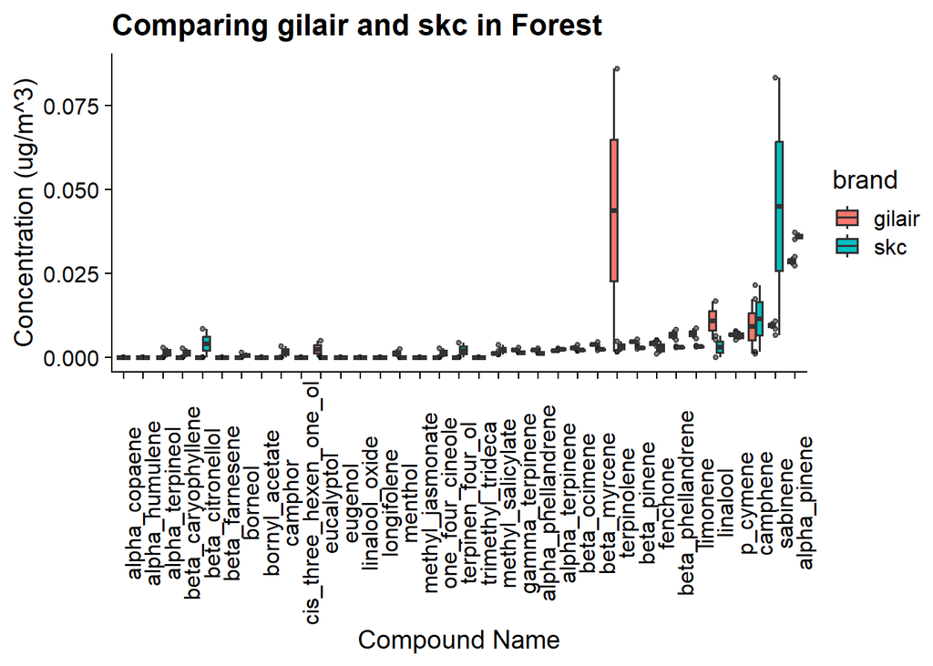

```r
forest_comp <- dat_smol|>
  filter(location == "forest") |>
  filter_out(type == "control") |>
  ggplot(aes(x = forcats::fct_reorder(peak_name, conc_ugcm, median),
    y = conc_ugcm,
    fill = brand)) +
  geom_point(alpha = 0.5, size = 1) +
  geom_boxplot() +
  theme( axis.text.x = element_text(
    angle = 90)) +
  labs(title = "Comparing gilair and skc in Forest",
       x = "Compound Name",
       y = "Concentration (ug/m^3)")

forest_comp
```

# Comparing city skc and gilair

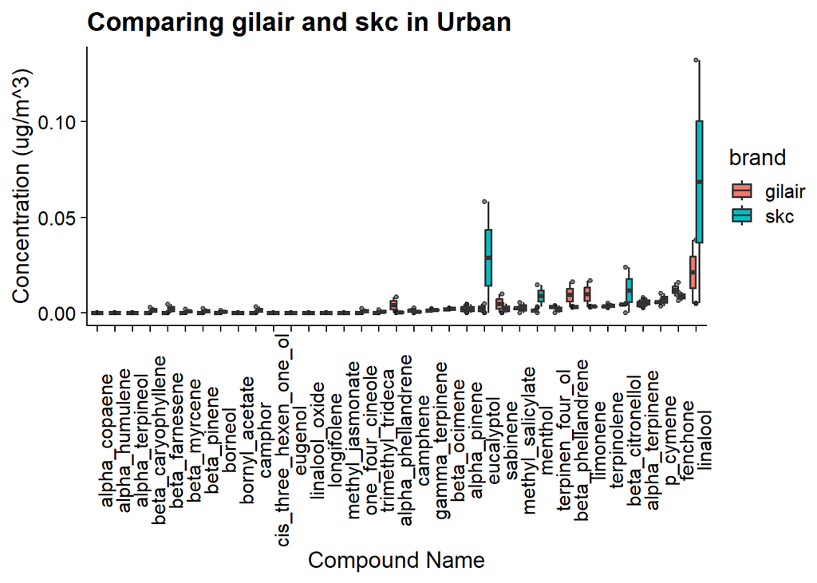

```r
city_comp <- dat_smol|>
  filter(location == "urban") |>
  filter_out(type == "control") |>
  ggplot(aes(x = forcats::fct_reorder(peak_name, conc_ugcm, median),
    y = conc_ugcm,
    fill = brand)) +
  geom_point(alpha = 0.5, size = 1) +
  geom_boxplot() +
  theme( axis.text.x = element_text(
    angle = 90)) +
  labs(title = "Comparing gilair and skc in Urban",
       x = "Compound Name",
       y = "Concentration (ug/m^3)")

city_comp
```

# Pooling both skc and gilair to get an idea of forest vs urban

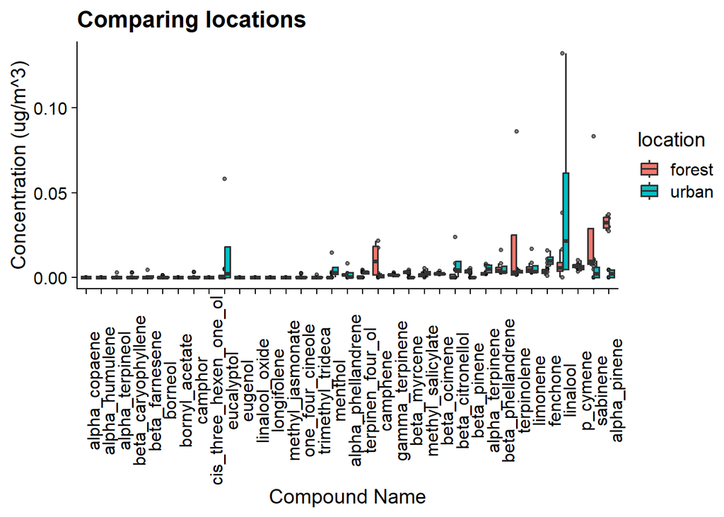

```r
location_comp <- dat_smol |>
  filter(type != "control") |>
  ggplot(aes(x = forcats::fct_reorder(peak_name, conc_ugcm, median),
    y = conc_ugcm,
    fill = location)) +
  geom_point(alpha = 0.5, size = 1) +
  geom_boxplot(outlier.shape = NA) +
  theme( axis.text.x = element_text(
    angle = 90)) +
  labs(title = "Comparing locations",
       x = "Compound Name",
       y = "Concentration (ug/m^3)")

location_comp
```

# Trying a quick heatmap???

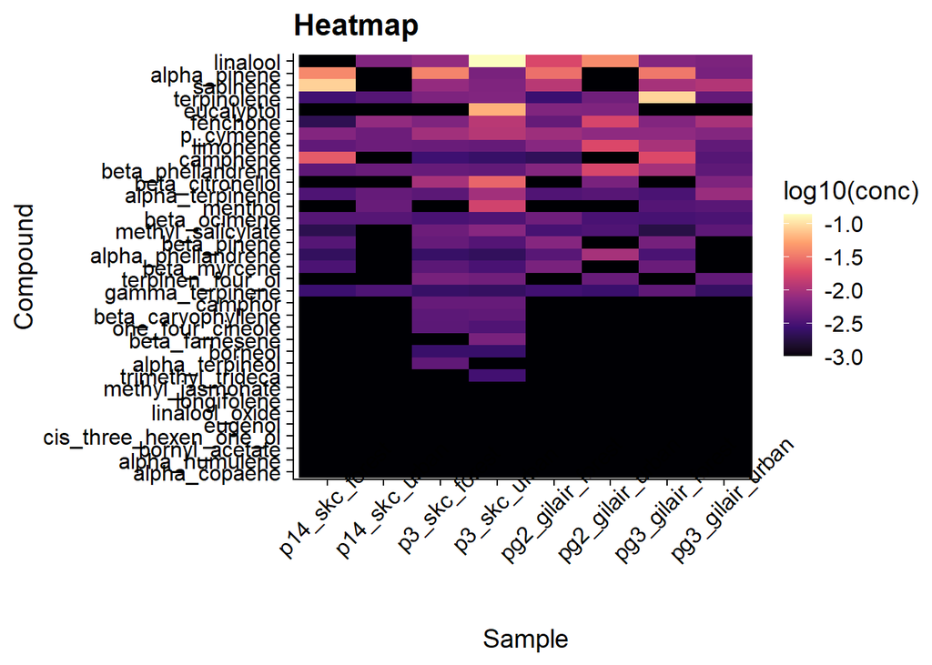

```r
heat_map <- dat_smol |>
  filter(type != "control") |>
  ggplot(aes(id, forcats::fct_reorder(peak_name, conc_ugcm, mean), fill = log10(conc_ugcm + 0.001))) +
  geom_tile() +
    scale_fill_viridis_c(
    option = "magma",
    direction = 1,
    name = "log10(conc)"
  ) +
   theme( axis.text.x = element_text(
    angle = 45, )) +
    labs(title = "Heatmap",
    x = "Sample",
    y = "Compound")

heat_map
```

# export for metaboanalyst

```r
uw_metabo <- dat_smol |>
  filter(type != "control") |>
  select(location, peak_name, id, conc_ugcm) |>
  pivot_wider(names_from = peak_name, values_from = conc_ugcm) |>
  select(id, everything())

write.csv(uw_metabo, "uw_metabo_1.csv")
```

- This was placed into metaboanalyst

Student’s T-test using raw p value of 0.05 significant: beta-myrcene (higher in forest) beta-pinene (higher in forest) alpha-pinene (higher in forest) fenchone (higher in urban)

However none of these are significant within the FDR range.

```r
t_test_results <- read.csv("t_test_of_UW_forestcity.csv")

print(t_test_results)
```

```
             X  t.stat  p.value X.log10.p.     FDR
1 beta_myrcene  3.3691 0.015059     1.8222 0.17112
2  beta_pinene  3.3554 0.015316     1.8149 0.17112
3 alpha_pinene  3.1826 0.019013     1.7210 0.17112
4     fenchone -2.8244 0.030179     1.5203 0.20371
```

-PCA Plot

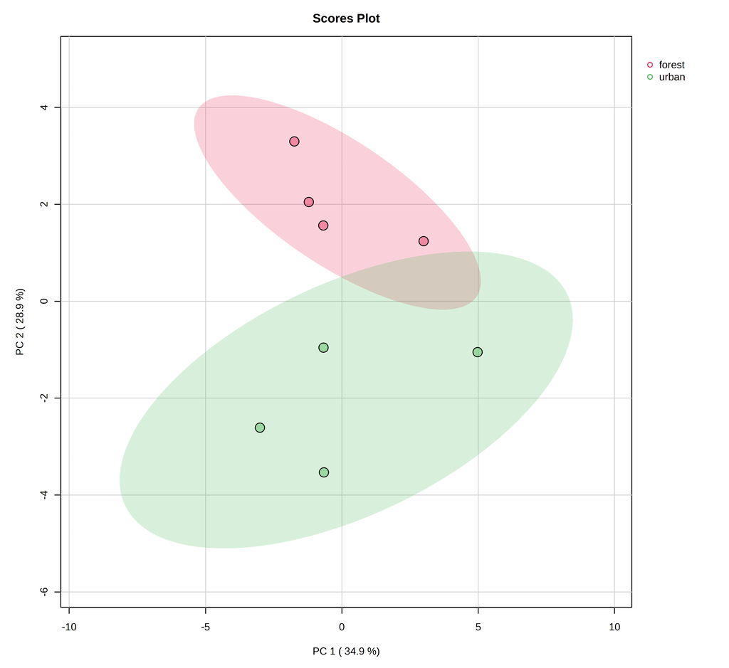

```r
knitr::include_graphics("pca_score2d_0_dpi300.png")
```

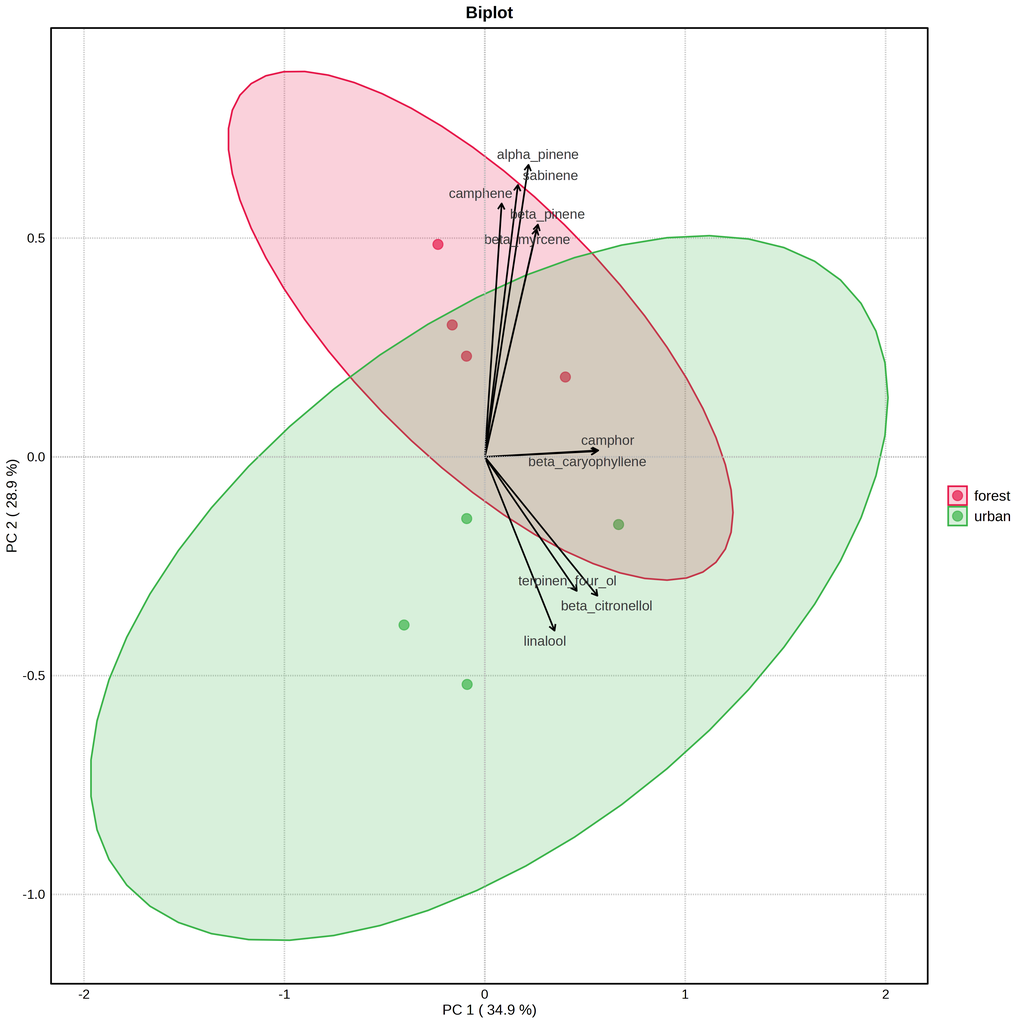

```r
knitr::include_graphics("pca_biplot_0_dpi300.png")
```

-PLSDA Plot

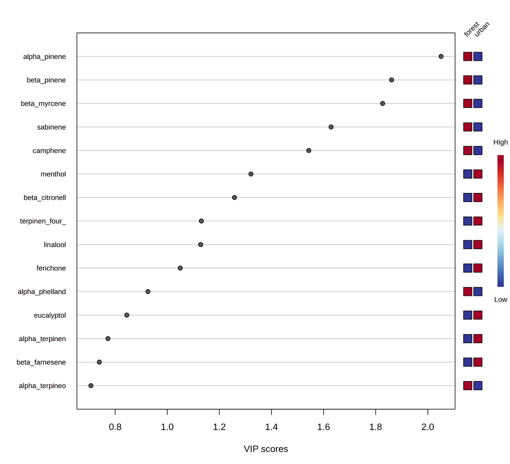

```r
knitr::include_graphics("pls_imp_0_dpi300.png")
```

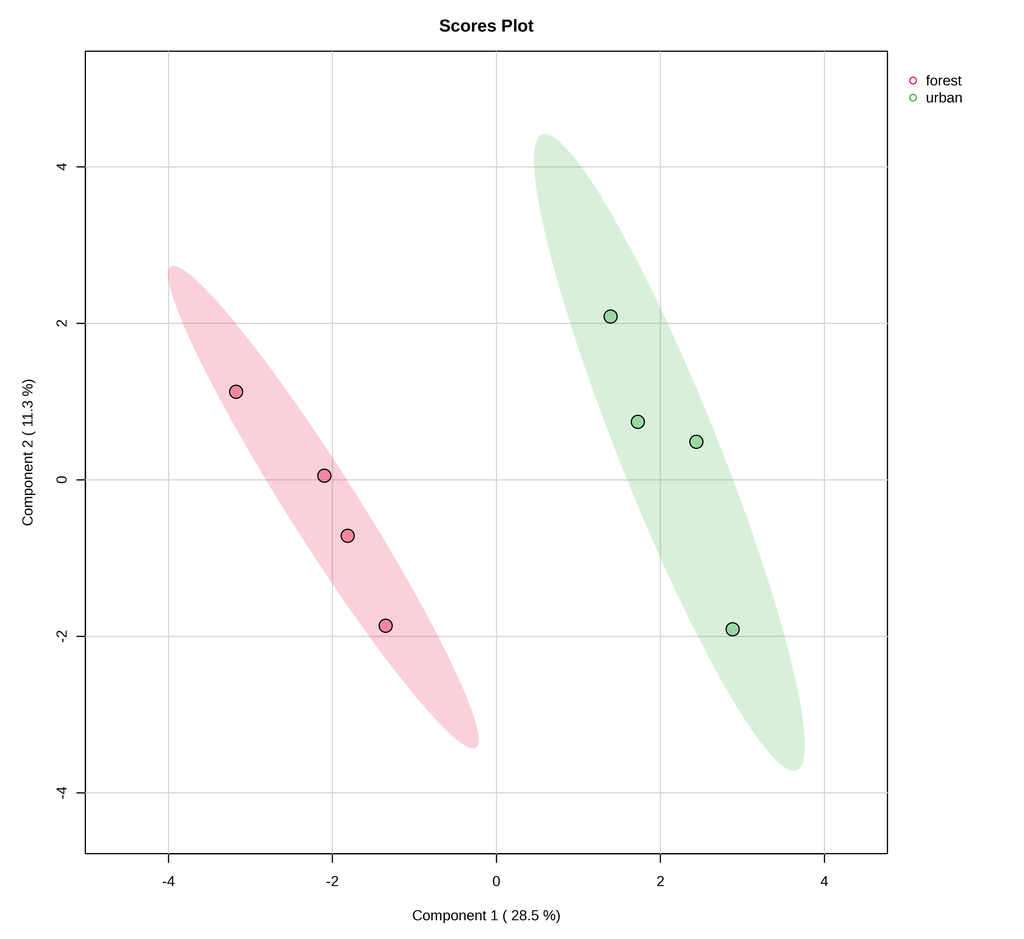

```r
knitr::include_graphics("pls_score2d_0_dpi300.png")
```

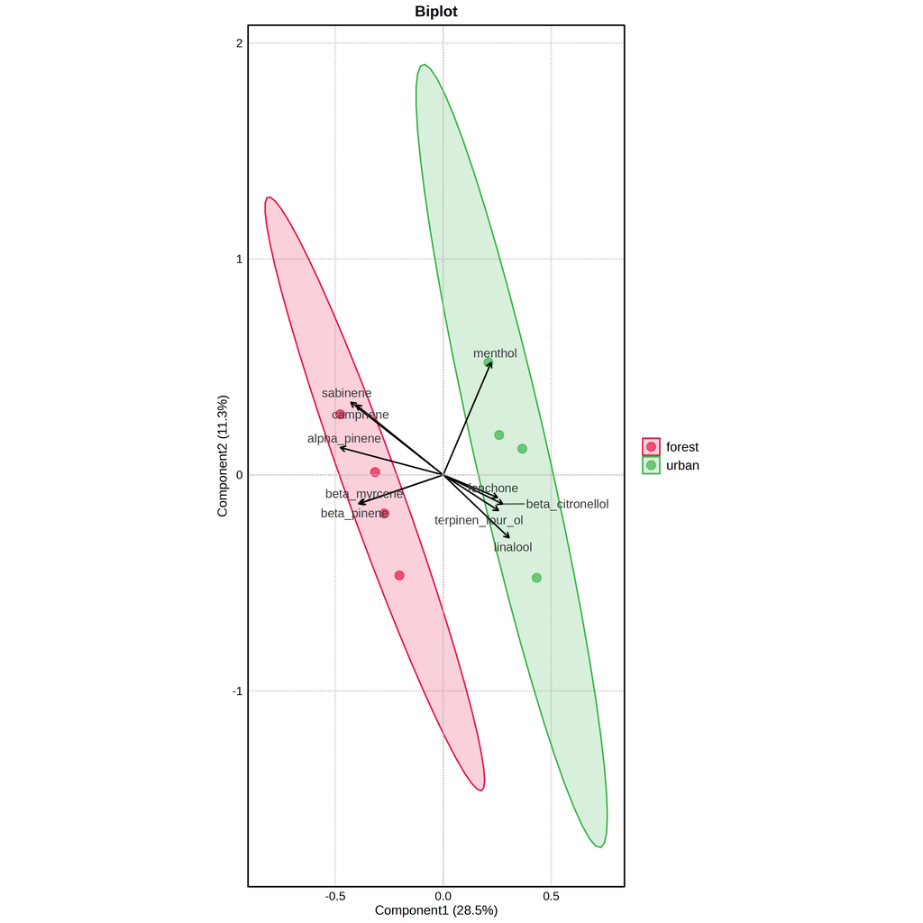

```r
knitr::include_graphics("pls_biplot_0_dpi300.png")
```

- Heatmap

Un-averaged and organized to have forest on one side and city on the other

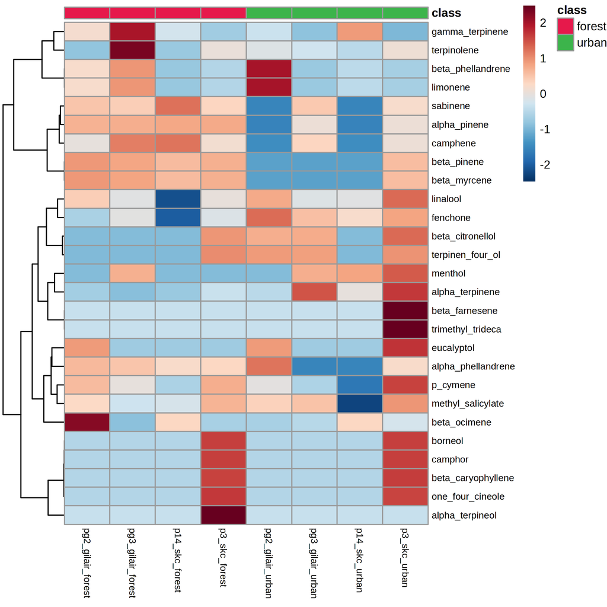

```r
knitr::include_graphics("heatmap_2_dpi300.png")
```

Grouped by average

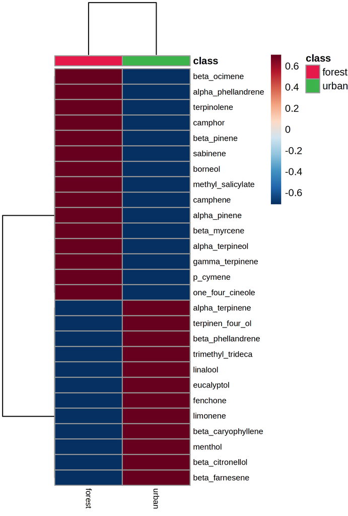

```r
knitr::include_graphics("heatmap_6_dpi300.png")
```